# herminR 0.5.1: validation report

9 of 9 checks passed; generated in 0.9 min by `tools/validation/run-validation.R`. All numbers are in `validation-results-0.5.1.rds`.

| item | value |
| --- | --- |
| Date | 2026-10-22 19:02 CEST |
| R | R version 4.3.3 (2024-02-29) |
| Platform | x86_64-pc-linux-gnu |
| herminR | 0.5.1 |
| ggplot2 | 3.4.4 |
| shiny | 1.8.0 |
| rsm | 2.10.6 |
| testthat | 3.2.1 |
| tibble | 3.2.1 |
| dplyr | 1.1.4 |
| rlang | 1.1.3 |

## Summary

| check | result |
| --- | --- |
| Reproduction of the paper's heatmaps | PASS |
| MPI against brute force | PASS |
| Interval coverage by simulation | PASS |
| Bootstrap rank stability in known scenarios | PASS |
| Feasible-region sampling converges from below | PASS |
| Contour view: the drawn step is the MPI | PASS |
| Edge cases: unusable data and unsafe constraints | PASS |
| Response times in the browser | PASS |
| Package check, test suite and browser tests | PASS |

## 1. Reproduction of the paper's heatmaps PASS

Does herminR give the values of the paper's own code for all 14 supplement heatmaps?

1520 cells compared with the output of the supplement's `heatmapVisualization()`; largest absolute difference 1.4e-14.

| study | figure | cells | missing | max_abs_diff |
| --- | --- | --- | --- | --- |
| pastry | main | 12 | 0 | 0 |
| pastry | main_quad | 12 | 0 | 4.441e-16 |
| pastry | all | 12 | 0 | 4.441e-16 |
| pastry | all_perResp | 12 | 0 | 5.551e-16 |
| pastry | abs_perResp | 12 | 0 | 5.551e-16 |
| pastry | subset | 8 | 0 | 4.718e-16 |
| pastry | range | 12 | 0 | 4.718e-16 |
| sim | main | 220 | 0 | 3.553e-15 |
| sim | main_quad | 220 | 0 | 7.105e-15 |
| sim | all | 220 | 0 | 1.421e-14 |
| sim | all_perResp | 220 | 0 | 5.551e-16 |
| sim | abs_perResp | 220 | 0 | 5.551e-16 |
| sim | subset | 120 | 0 | 5.551e-16 |
| sim | range | 220 | 0 | 5.551e-16 |

## 2. MPI against brute force PASS

Is MPI the largest one-unit change of the fitted surface, as defined?

300 random second-order models (2-5 factors, random main, quadratic and interaction terms), 1058 factor values. The brute force evaluates the polynomial over a grid of starting points (the factor from -1 to 0 in steps of 0.05, the others at -1, -0.5, 0, 0.5, 1) and takes the largest one-unit change. Largest |MPI - brute force| = 3.1e-15.

## 3. Interval coverage by simulation PASS

Do the intervals cover the true MPI as often as they claim?

Expectations: the ellipsoid interval is conservative (not significantly below 95%); the delta method is close to 95% when the effect is clearly away from zero; the SE soft-threshold has no coverage guarantee and is shown for information.

Observed for the delta method: Clear effect (MPI 1.5) 97.0%; Small effect (MPI 0.3) 96.5%; One term near zero (MPI 0.62) 86.3%. Coverage below nominal when a term is close to zero is the known weakness of the delta method, and the explorer says so next to the intervals.

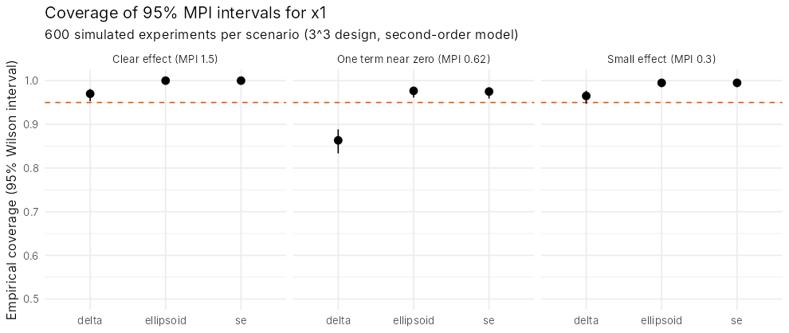

| scenario | method | true_mpi | coverage | wilson_low | wilson_high |
| --- | --- | --- | --- | --- | --- |
| Clear effect (MPI 1.5) | delta | 1.5 | 0.97 | 0.953 | 0.981 |
| Clear effect (MPI 1.5) | ellipsoid | 1.5 | 1 | 0.994 | 1 |
| Clear effect (MPI 1.5) | se | 1.5 | 1 | 0.994 | 1 |
| Small effect (MPI 0.3) | delta | 0.3 | 0.965 | 0.947 | 0.977 |
| Small effect (MPI 0.3) | ellipsoid | 0.3 | 0.995 | 0.985 | 0.998 |
| Small effect (MPI 0.3) | se | 0.3 | 0.995 | 0.985 | 0.998 |
| One term near zero (MPI 0.62) | delta | 0.62 | 0.863 | 0.834 | 0.889 |
| One term near zero (MPI 0.62) | ellipsoid | 0.62 | 0.977 | 0.961 | 0.986 |
| One term near zero (MPI 0.62) | se | 0.62 | 0.975 | 0.959 | 0.985 |

## 4. Bootstrap rank stability in known scenarios PASS

Does the bootstrap report a stable leader when there is one, and an unstable ranking for a near tie?

300 residual-bootstrap replays each. Expected: with a clear leader, x1 first in (almost) every replay and a rank interval of 1-1; with equal true effects, neither x1 nor x2 first in more than 95% of replays and both rank intervals spanning 1-2. (The bootstrap varies the data around the *fitted* model, so a true tie shows up as an unstable ranking, not as an exact 50/50 split.)

| scenario | factor | top1_frac | rank_lower | rank_upper |
| --- | --- | --- | --- | --- |
| clear leader (1.2 vs 0.3) | x1 | 1 | 1 | 1 |
| clear leader (1.2 vs 0.3) | x2 | 0 | 2 | 2 |
| clear leader (1.2 vs 0.3) | x3 | 0 | 3 | 3 |
| near tie (1.2 vs 1.2) | x1 | 0.117 | 1 | 2 |
| near tie (1.2 vs 1.2) | x2 | 0.883 | 1 | 2 |
| near tie (1.2 vs 1.2) | x3 | 0 | 3 | 3 |

## 5. Feasible-region sampling converges from below PASS

Is a sampled feasible-region MPI a lower estimate that approaches the exact value as samples increase?

Box region x3 in [-0.5, 0.5] (exact value known), LHS, 5 sizes x 5 seeds. Every sampled value is at or below the exact value, and the worst gap shrinks with the sample size.

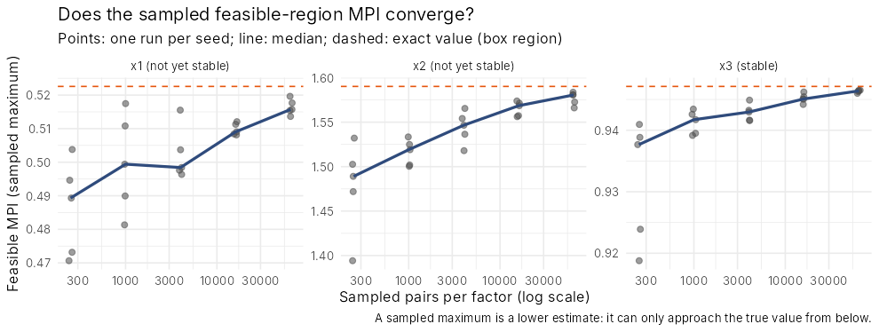

| factor | estimate | spread | last_change | gap_to_exact | min_feasible | stable |
| --- | --- | --- | --- | --- | --- | --- |
| x1 | 0.516 | 0.0116 | 0.013 | 0.00563 | 250 | FALSE |
| x2 | 1.58 | 0.0111 | 0.00767 | 0.00412 | 250 | FALSE |
| x3 | 0.946 | 0.000526 | 0.00139 | 0.000656 | 250 | TRUE |

Constraint x1 + x2 <= 0 (no exact value): look for a flat median.

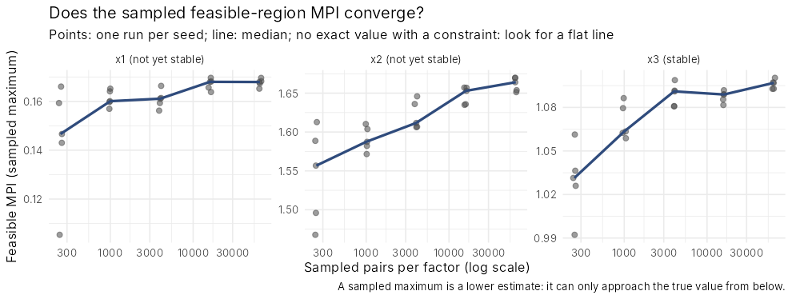

| factor | estimate | spread | last_change | gap_to_exact | min_feasible | stable |
| --- | --- | --- | --- | --- | --- | --- |
| x1 | 0.168 | 0.0263 | 0.000399 | NA | 57 | FALSE |
| x2 | 1.66 | 0.0111 | 0.0067 | NA | 57 | FALSE |
| x3 | 1.1 | 0.0069 | 0.0073 | NA | 121 | TRUE |

## 6. Contour view: the drawn step is the MPI PASS

Is the arrow in the contour view the one-unit change that defines MPI?

Pastry fit: the change along the arrow equals the MPI and the change predicted by `predict()`. Paper simulation: 118 factor-response cells, 0 mismatches.

| factor | mpi | step_change | predict_change |
| --- | --- | --- | --- |
| x1 | 0.552626 | -0.552626 | -0.552626 |
| x2 | 1.67902 | 1.67902 | 1.67902 |
| x3 | 1.11031 | -1.11031 | -1.11031 |

## 7. Edge cases: unusable data and unsafe constraints PASS

Are unusable data and unsafe constraints refused with a plain explanation, and are data problems reported?

The data checks run before any model is fitted; constraints are parsed and only arithmetic and comparisons on factor names are allowed.

| case | outcome | message |
| --- | --- | --- |
| valid 3^3 design | accepted |  |
| text in a factor | refused | Factor 'x3' must contain numbers, but it contains text such as 'lo', 'mid', 'hi'. Code categorical settings as numbers, or use the column as a block. |
| text in the response | refused | Response 'y' must contain numbers, but it contains text such as 'good', 'bad', 'ok'. |
| factor with a single value | refused | Factor 'x3' takes a single value (5) in the runs used, so its effect cannot be studied: remove it from the factors. |
| 8 runs for a 10-term model | refused | y: 8 runs for a model with 10 terms leaves no degrees of freedom, so the model cannot be estimated reliably and no uncertainty can be computed. At least 11 runs |
| missing responses | noted | 2 runs with missing values (in y) are left out: 25 of 27 runs are used. |
| two-level factor, second-order model | noted | Factor 'x3' has only two levels, so its quadratic effect cannot be estimated and is left out. |
| constraint x1 + x2 <= 0 | accepted | accepted |
| constraint system('ls') | refused | Function `system` is not allowed in a constraint. |
| constraint x1 + | refused | Constraint is not a valid expression: <text>:2:0: unexpected end of input 1: x1 + ^ |
| constraint x9 > 0 | refused | Unknown name `x9` in constraint; use factor names: "x1", "x2", and "x3". |
| constraint rep(TRUE, 3) | refused | Function `rep` is not allowed in a constraint. |

## 8. Response times in the browser PASS

Does every action respond within 5 seconds on the reference data sets, including a 729-run, 4-response study?

Slowest action: Download the HTML report (synthetic), 2.36 s. Full tables, including computation times and memory, in `benchmark-0.5.1.html`.

| study | action | seconds |
| --- | --- | --- |
| pastry | Open the app | 0.593 |
| pastry | Load data and fit models | 0.162 |
| pastry | Change the norm (L1 to L2) | 0.043 |
| pastry | Change the norm back | 0.049 |
| pastry | Open the term Sankey | 0.178 |
| pastry | Open the contour view (first time) | 0.13 |
| pastry | Open the contour view again (cached) | 0.039 |
| pastry | Go to Uncertainty (intervals drawn) | 0.325 |
| pastry | Change the interval level | 0.21 |
| pastry | Run bootstrap (200 replicates) | 1.53 |
| pastry | Go to Robustness and run selection paths | 0.618 |
| pastry | Run feasible-region sampling (5000) | 0.07 |
| pastry | Check convergence (12 runs) | 0.403 |
| pastry | Download the HTML report | 2.22 |
| synthetic | Open the app | 0.6 |
| synthetic | Fit 4 models on 729 runs (choose factors) | 0.046 |
| synthetic | Change the norm (L1 to L2) | 0.068 |
| synthetic | Change the norm back | 0.052 |
| synthetic | Open the term Sankey | 0.205 |
| synthetic | Open the contour view (first time) | 0.87 |
| synthetic | Open the contour view again (cached) | 0.047 |
| synthetic | Go to Uncertainty (intervals drawn) | 0.543 |
| synthetic | Change the interval level | 0.522 |
| synthetic | Run bootstrap (200 replicates) | 2.34 |
| synthetic | Go to Robustness and run selection paths | 1.42 |
| synthetic | Run feasible-region sampling (5000) | 0.209 |
| synthetic | Check convergence (12 runs) | 1.64 |
| synthetic | Download the HTML report | 2.36 |
| simulation | Open the app | 0.69 |
| simulation | Load data (coefficients) | 0.245 |
| simulation | Change the norm (L1 to L2) | 0.235 |
| simulation | Change the norm back | 0.236 |
| simulation | Open the term Sankey | 0.335 |
| simulation | Download the HTML report | 2.11 |

## 9. Package check, test suite and browser tests PASS

Does the released tarball pass R CMD check and the full test suite without failures, warnings or skips?

| log | result |
| --- | --- |
| R-CMD-check-0.5.1.log | Status: OK |
| full-tests-0.5.1-ggplot2-4.0.0.log | files: 21 tests: 157 expectations: 1348 failed: 0 warnings: 0 skipped: 0 errors: 0 |
| full-tests-0.5.1.log | files: 21 tests: 157 expectations: 1348 failed: 0 warnings: 0 skipped: 0 errors: 0 |

```
herminR 0.5.1 browser checks, 2026-10-22T16:50Z
R 4.3.3 | shiny 1.8.0 | ggplot2 3.4.4
== happy_path
PASS opens on Start here
PASS example goes to step 2
PASS stepper greys out unavailable stages
PASS step 3 explains why it is unavailable
PASS step 3 controls hidden for coefficient-only data
PASS 'Go to Data' button navigates to step 1
PASS stages become available with raw data
PASS blocked pastry model gives the reference MPI (x2: 1.68)
PASS intervals shown with fitted models
PASS Run bootstrap is disabled while running
PASS Run bootstrap re-enabled afterwards
PASS bootstrap shows last-run details
PASS stale-result warning after changing settings
PASS example fills the constraint
PASS sampling waits for the button
PASS sampled result labelled Approximate
PASS report has findings and embedded plots
PASS bookmark link generated
PASS link restores the data source
PASS link restores the same model and results
PASS link restores the current stage
PASS no visible errors

0 failure(s)
== interaction
PASS hovering the heatmap shows a tooltip for x2 on y
PASS tooltip gives the MPI (1.679) and the rank (1 of 3)
PASS click highlights x2 (bar on every stage)
PASS highlight carried to the Uncertainty stage
PASS interval plot tooltip with the interval
PASS snapshot kept
PASS comparison describes both settings
PASS rank comparison plot drawn
PASS link restores the highlighted factor
PASS link restores the snapshot and comparison
PASS per-factor scaling changes rankings (dss_sim)
0 failure(s)
== flows
PASS term Sankey drawn
PASS anatomy note explains the y4 decomposition
PASS interaction network drawn
PASS click away from factors highlights nothing
PASS factor-to-response Sankey drawn
PASS contour view drawn
PASS contour note gives the MPI step of x2 (1.679)
PASS bootstrap rank flow drawn
0 failure(s)
== viewports
PASS 1440x900: heatmap height 558 px within 360-640
PASS 1440x900: no horizontal page scroll (content 1440 px)
PASS 1440x900: heatmap has a text alternative
PASS 1280x800: heatmap height 496 px within 360-640
PASS 1280x800: no horizontal page scroll (content 1280 px)
PASS 1280x800: heatmap has a text alternative
PASS keyboard: 'Highlight a factor' selects x3
PASS keyboard: Enter opens the collapsed values table
PASS no empty 'More' menu while the Advanced View is off
PASS Advanced View appears under 'More' when switched on
PASS 1024x768: heatmap height 476 px within 360-640
PASS 1024x768: no horizontal page scroll (content 1024 px)
PASS 1024x768: heatmap has a text alternative
PASS 768x1024: heatmap height 635 px within 360-640
PASS 768x1024: no horizontal page scroll (content 768 px)
PASS 768x1024: heatmap has a text alternative
PASS 390x844: heatmap height 523 px within 360-640
PASS 390x844: no horizontal page scroll (content 390 px)
PASS 390x844: heatmap has a text alternative
0 failure(s)
screenshots: /tmp/tmp.CrQBJo4sTK
```